# Fairness in Machine Learning: An Introduction

## Introduction

In this short lecture, we’ll discuss issues at the intersection of machine learning and fairness. In particular, we will cover:

- What is a machine learning model?
- Evaluating machine learning models
- Auditing for algorithmic bias via “slicing analysis”
- A case study using real-world data in R

## What is a machine learning model?

## Machine Learning Model

- A mathematical **function** that relates **inputs** to **outputs**.
- We can represent this as \(\hat{y} = f_{\theta}(x)\), where:
  - \(\hat{y}\) is the prediction for a given input (our **estimate** of the true label \(y\))
  - \(f_{\theta}\) is our “model” with parameters \(\theta\) that control its predictions
  - \(x\) is an input observation

## An example model

Consider a model where our goal is to predict whether a loan applicant is “high” or “low” risk, using a historical dataset of loan applications as follows:

- \(x\) is a set of features about the loan applicant (checking & savings account status, age job, etc.).
- \(y\) is whether that individual was a high or low risk (i.e., whether they defaulted on a loan).

We can use this data to “train” a model \(f_\theta\) to predict the creditworthiness of future applicants from this same set of features.

## An example dataset

We’ll consider the German Credit Dataset.

```r
german_credit %>%
  select(c("chk_acct", "duration", "credit_his", "purpose",
           "amount", "present_emp", "sex", "age", "response")) %>%
  str()
```

```
## 'data.frame':    1000 obs. of  9 variables:
##  $ chk_acct   : Factor w/ 4 levels "A11","A12","A13",..: 1 2 4 1 1 4 4 2 4 2 ...
##  $ duration   : int  6 48 12 42 24 36 24 36 12 30 ...
##  $ credit_his : Factor w/ 5 levels "A30","A31","A32",..: 5 3 5 3 4 3 3 3 3 5 ...
##  $ purpose    : Factor w/ 10 levels "A40","A41","A410",..: 5 5 8 4 1 8 4 2 5 1 ...
##  $ amount     : int  1169 5951 2096 7882 4870 9055 2835 6948 3059 5234 ...
##  $ present_emp: Factor w/ 5 levels "A71","A72","A73",..: 5 3 4 4 3 3 5 3 4 1 ...
##  $ sex        : Factor w/ 4 levels "A91","A92","A93",..: 3 2 3 3 3 3 3 3 1 4 ...
##  $ age        : int  67 22 49 45 53 35 53 35 61 28 ...
##  $ response   : Factor w/ 2 levels "0","1": 1 2 1 1 2 1 1 1 1 2 ...
```

## Training our model

Below, we train a prediction model using the XGBoost algorithm to predict credit risk from the input features.

This is an important task, and the input features here are sensitive (and legally-protected in the United States). How do we know whether this model is “good”, or “fair”?

```r
xgb_model <- train(response~.,
                   data=german_train,
                   metric='Accuracy',
                   trControl = xgb_trcontrol,
                   tuneGrid = xgbGrid,
                   method = "xgbTree")
```

## Evaluating machine learning models

## Measuring model performance

Typically, we use a “test” dataset – a set of unseen data not used for training – to evaluate the quality of our model.

Using this test set, we make *predictions* \(f_{\theta}(x_i)\) for each element \(x_i\) in the test set, and compare this to the true labels \(y_i\).

From this set of paired predictions and labels, we compute metrics to measure model performance. Common metrics for classification tasks include:

- **Accuracy**
- **Cross-entropy**
- Metrics from the **confusion matrix**, including:
  - **False Positive Rate (FPR)**
  - **True Positive Rate (TPR)**

## Inspecting our model’s performance

**Predictions and Labels**

```r
head(labs, n=20)  # The true labels
```

```
##  [1] 1 0 1 1 0 0 0 0 0 0 0 0 0 0 1 0 0 0 1 0
## Levels: 0 1
```

```r
head(preds, n=20) # Our model's predictions
```

```
##  [1] 1 0 1 1 0 1 0 0 0 0 1 0 0 0 1 0 0 0 0 0
## Levels: 0 1
```

## Inspecting our model’s performance

**Confusion Matrix:**

```
##           Reference
## Prediction   0   1
##          0 137  41
##          1  33  39
```

**Model Performance:**

```
##       TPR       FPR  Accuracy
## 0.8058824 0.5125000 0.7040000
```

## The Receiver Operating Characteristic (ROC) Curve

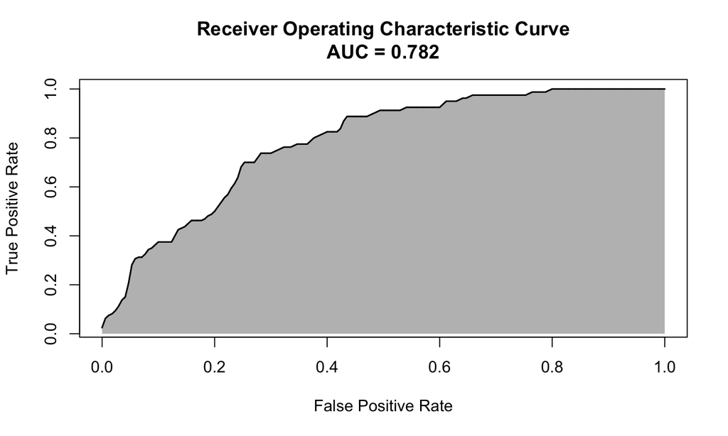

## Measuring and Detecting Bias in Machine Learning Algorithms

## What is “algorithmic bias?”

**Algorithmic bias** describes *systematic and repeatable errors in a computer system that create “unfair” outcomes, such as “privileging” one category over another in ways different from the intended function of the algorithm.* <sup>1</sup>

Measuring, mitigating, and preventing algorithmic bias is an emerging field in machine learning research.

Algorithmic bias can occur in any system reliant on algorithms, and has been widely documented in existing systems from criminal justice (Angwin et al. (2018)) to image classification (Buolamwini and Gebru (2018)).

The procedure of evaluating performance on individual subgroups is sometimes referred to as **slicing analysis** (Sculley et al. (2018)) and is an important first step in auditing any statistical model.

## Case Study: Measuring Algorithmic Bias

There are many ways we can measure algorithmic bias using the metrics we discussed before.

For example, we can assess **accuracy disparity** by comparing the accuracies across two demographic groups (here, by age).

```r
testdata %>% group_by(age_gt30) %>% summarise(acc=mean(is_correct))
```

```
## # A tibble: 2 × 2
##   age_gt30   acc
##   <fct>    <dbl>
## 1 FALSE    0.642
## 2 TRUE     0.742
```

## Case Study: Measuring Algorithmic Bias

We can also measure bias via **Absolute Betweeen-ROC Area (ABROCA)** (Gardner, Brooks, and Baker (2019)).

To compute ABROCA, we measure the area between two subgroup-specific ROC curves (shown below for age >= 30).

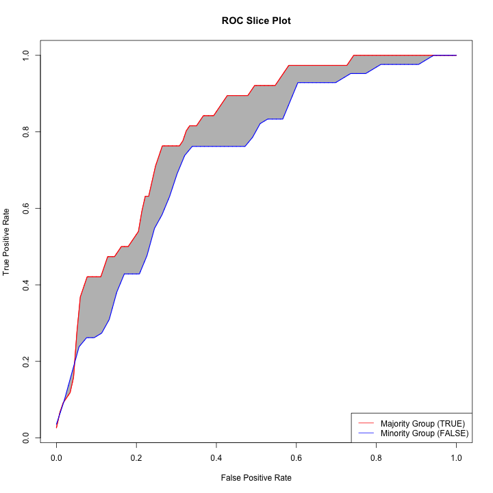

## Choosing Metrics for Slicing Analysis

As mentioned before, there are several ways we might choose to measure bias in any machine learning model.

**Accuracy Disparity** may be useful when we desire a classifier that:

- Has low algorithmic bias at a specific threshold.

**ABROCA** may be useful when we desire a classifier that:

- Has low algorithmic bias across all classification thresholds.
- Has good performance even on unbalanced datasets.

The “right” evaluation metric will always depend on context. Every individual involved in a model’s development is responsible to ensure that it is evaluated with appropriate metrics.

## Summary

## Fairness in Machine Learning: Key Takeaways

- Machine learning models are trained to make predictions from data based on past observations.
- **Algorithmic bias** can emerge when these systems systematically treat groups differently in unintended ways.
- We can measure this bias using a variety of tools, including disparity metrics and ABROCA.
- Ultimately, our choice of bias metrics should reflect our specific task and what constitutes an acceptably “fair” model for that task.

## References

## References

Angwin, Julia, Jeff Larson, Surya Mattu, and Lauren Kirchner. 2018. *Machine Bias*. Auerbach Publications.

Buolamwini, Joy, and Timnit Gebru. 2018. *Gender Shades: Intersectional Accuracy Disparities in Commercial Gender Classification*. PMLR.

Gardner, Josh, Christopher Brooks, and Ryan Baker. 2019. *Evaluating the Fairness of Predictive Student Models Through Slicing Analysis*.

Sculley, David, Jasper Snoek, Alex Wiltschko, and Ali Rahimi. 2018. “Winner’s Curse? On Pace, Progress, and Empirical Rigor.”